# CD91_sarcoma_explore.Rmd

Teddy

06/09/2019

## CD91 Sarcoma Exploration

This code downloads the TCGA Sarcoma datasets from the cBioportal and looks at expression data related to the CD91 gene. The data will be split apart in multiple ways to compare disease status and related metrics to the level of CD91 mRNA expression.

We are looking to extract and explore the data seen here, which has many other features and expressed genes to explore:

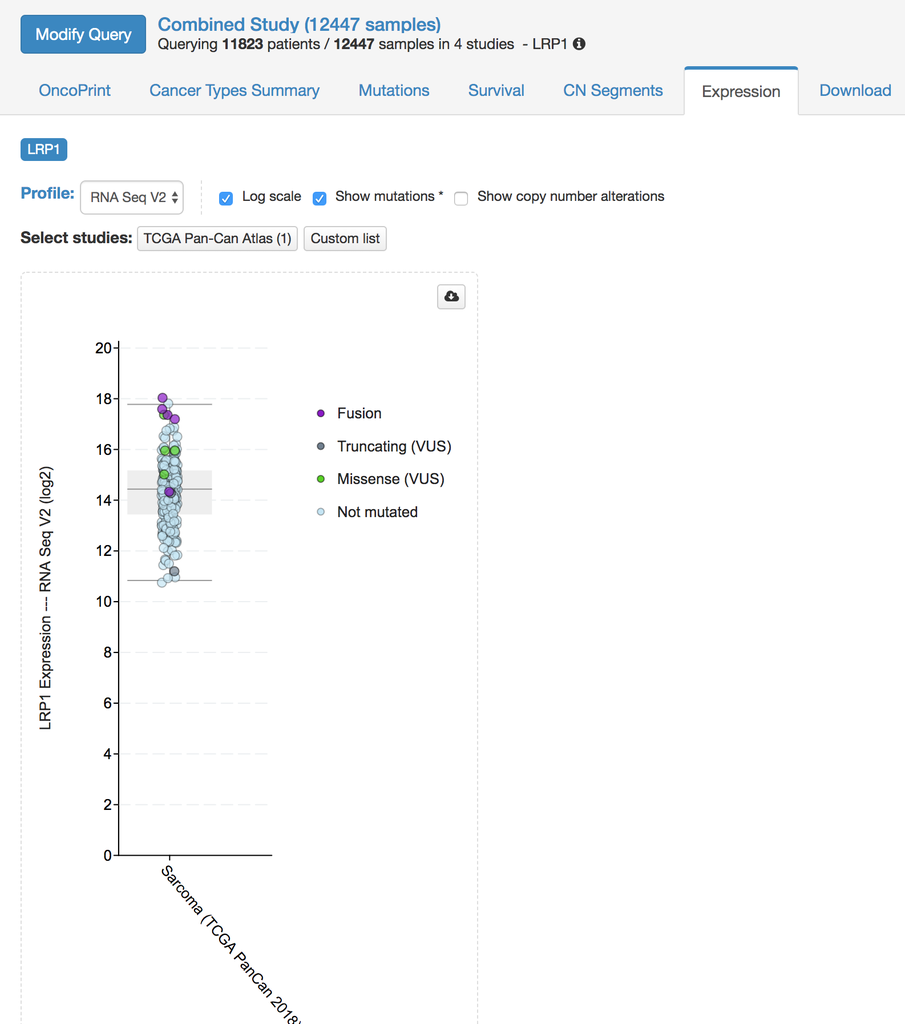

Any acronyms or ambiguous abbreviations can be resolved by looking at the Swagger API for cBioPortal http://oncotree.mskcc.org/cdd/swagger-ui.html#/

### Set up environment

Here I load the relevant packages and set environment variables. Specialty package `cgdsr` is loaded from the [cBioportal](http://www.cbioportal.org/) website.

### Download the datasets

Use the cBio package to download TCGA PanCancer Atlas sarcoma cancer data from [here](http://www.cbioportal.org/study/summary?id=sarc_tcga_pan_can_atlas_2018).

[output not shown]

### Pull Sarcoma Samples

Use the downloaded data to find the TCGA sarcoma data and isolate the RNA-seq expression data for all samples with such data.

```r
#' @get available genetic profiles strings
sarc_genetic_profiles_RNAseq <- getGeneticProfiles(mycgds, target_study_id)[2,1]
sarc_genetic_profiles_muts <- getGeneticProfiles(mycgds, target_study_id)[5,1]



#' @get data slices for a specified list of genes, genetic profile and case list
RNAseq_profile_data <- getProfileData.CGDS(x = mycgds,
                                           genes = c('LRP1'),
                                           geneticProfiles = sarc_genetic_profiles_RNAseq,
                                           caseList = sarc_caselist_id)


MUT_profile_data <- getProfileData.CGDS(x = mycgds,
                                        genes = c('LRP1'),
                                        geneticProfiles = sarc_genetic_profiles_muts,
                                        caseList = sarc_caselist_id)


#' @get clinical data for the target sarcoma case list
sarc_clinical_data <- getClinicalData.CGDS(x = mycgds, caseList = sarc_caselist_id)

#' @get available mutation data for the sarcoma cancer study
sarc_mutation_data <- getMutationData.CGDS(x = mycgds,
                                           caseList = sarc_caselist_id,
                                           geneticProfile = sarc_genetic_profiles_muts,
                                           genes = 'LRP1')
```

### Create combined set

We have pulled all of the expression data, mutation data, and clinical data for all out samples in the target sarcoma studies. Now we need to combine them into a master sheet

```r
#'[format the data]
#' @create case_id column and convert to data.table
RNAseq_profile_data$case_id <- row.names(x = RNAseq_profile_data)
RNAseq_profile_data <- data.table(RNAseq_profile_data)
setnames(x = RNAseq_profile_data, old = "LRP1", new = "LRP1_mrna_TPM")

#' @create case_id column and convert to data.table
# MUT_profile_data$case_id <- row.names(x = MUT_profile_data)
# MUT_profile_data <- data.table(MUT_profile_data)
# setnames(x = MUT_profile_data, old = "LRP1", new = "mutation")
#' [not needed]

#' @format data and remove non-important rows
sarc_clinical_data$case_id <- row.names(x = sarc_clinical_data)
sarc_clinical_data <- data.table(sarc_clinical_data)
sarc_clinical_data <- sarc_clinical_data[,.(case_id, AGE, ANEUPLOIDY_SCORE, CANCER_TYPE,
                                            CANCER_TYPE_ACRONYM, CANCER_TYPE_DETAILED,
                                            DAYS_LAST_FOLLOWUP, DFS_MONTHS, DFS_STATUS,
                                            DSS_MONTHS, DSS_STATUS, ETHNICITY,
                                            FRACTION_GENOME_ALTERED, MUTATION_COUNT,
                                            NEW_TUMOR_EVENT_AFTER_INITIAL_TREATMENT,
                                            OS_MONTHS, OS_STATUS,
                                            PFS_MONTHS, PFS_STATUS, RACE, SEX,
                                            TUMOR_TISSUE_SITE, TUMOR_TYPE)]
#' @format the mutation data
sarc_mutation_data <- data.table(sarc_mutation_data)
sarc_mutation_data <- sarc_mutation_data[,.(case_id, mutation_type, amino_acid_change)]

#' [Merge the datasets into one]
#' @merge RNAseq and MUT profile
full_data <- merge(RNAseq_profile_data, sarc_mutation_data, by = "case_id", all.x = TRUE)
full_data <- merge(full_data, sarc_clinical_data, by = "case_id", all.x = TRUE)
```